# Laboratório 1, parte 4.

```r
atividade = read_projectdata()
```

# Descrição

Fazendo uso dos dados referentes aos tweets dos congressistas, resolvi dessa vez analisar a correlação entre o número de seguidores de um congressista com o seu engajamento total, bem como do número de pessoas que ele segue com o seu engajamento total. Seguidores e engaj total. Segue com engaj total.

## Primeira correlação

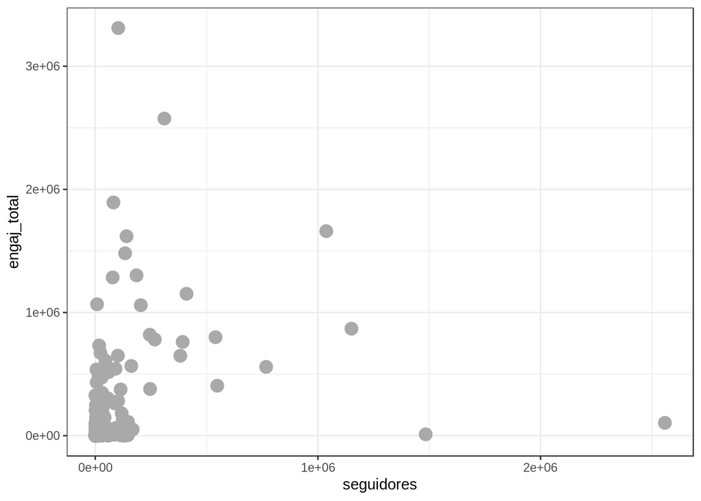

```r
 congressistas_com_twitter = atividade %>% filter(twitter != "NA")

 congressistas_com_twitter[is.na(congressistas_com_twitter)] = 0

 congressistas_com_twitter %>%
  ggplot(aes(x = seguidores, y = engaj_total)) +
  geom_point(colour = "darkgrey", size = 4)
```

```r
 congressistas_com_twitter %>%
   summarize(correlacao_pearson = cor(seguidores, engaj_total, method="pearson"),
             correlacao_spearman = cor(seguidores, engaj_total, method="spearman"),
             correlacao_kendall = cor(seguidores, engaj_total, method="kendall"))
```

```
## # A tibble: 1 x 3
##   correlacao_pearson correlacao_spearman correlacao_kendall
##                <dbl>               <dbl>              <dbl>
## 1              0.309               0.879              0.717
```

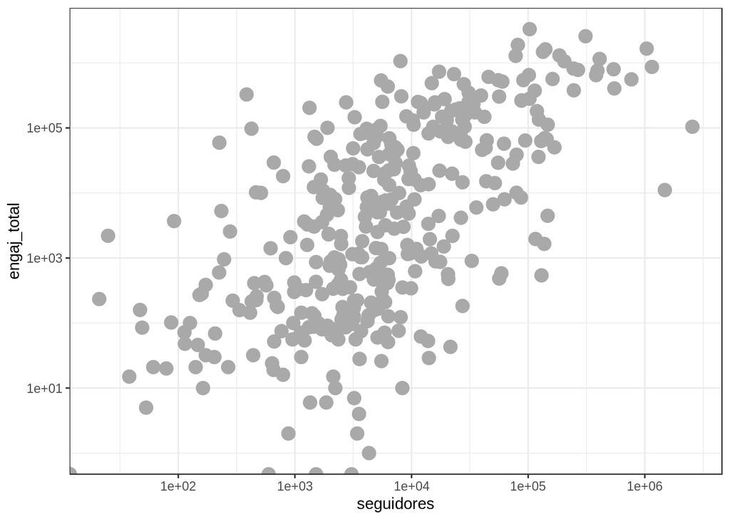

```r
 congressistas_com_twitter %>%
  ggplot(aes(x = seguidores, y = engaj_total)) +
  geom_point(colour = "darkgrey", size = 4) +
  scale_x_log10() +
  scale_y_log10()
```

### Conclusão da primeira correlação

Ao calcular a correlação por pearson obtivemos um valor baixo, mesmo após o tratamento dos dados (eliminação das tuplas nulas da tabela). Porém, ao calcular a correlação pelos outros coeficientes a correlação foi bem maior. Isso indica que não há uma correlação linear muito forte, mas existe correlação de outro tipo com uma magnitude bem maior. Ao plotar o gráfico em uma escala de log10 obtivemos uma visualização que se assemelha muito a uma reta, o que indica correlação linear. As variáveis tem uma relação polinomial, o que foi determinante para o formato do gráfico após a aplicação do log10. Essa relação é forte, positiva e polinomial.

## Segunda correlação

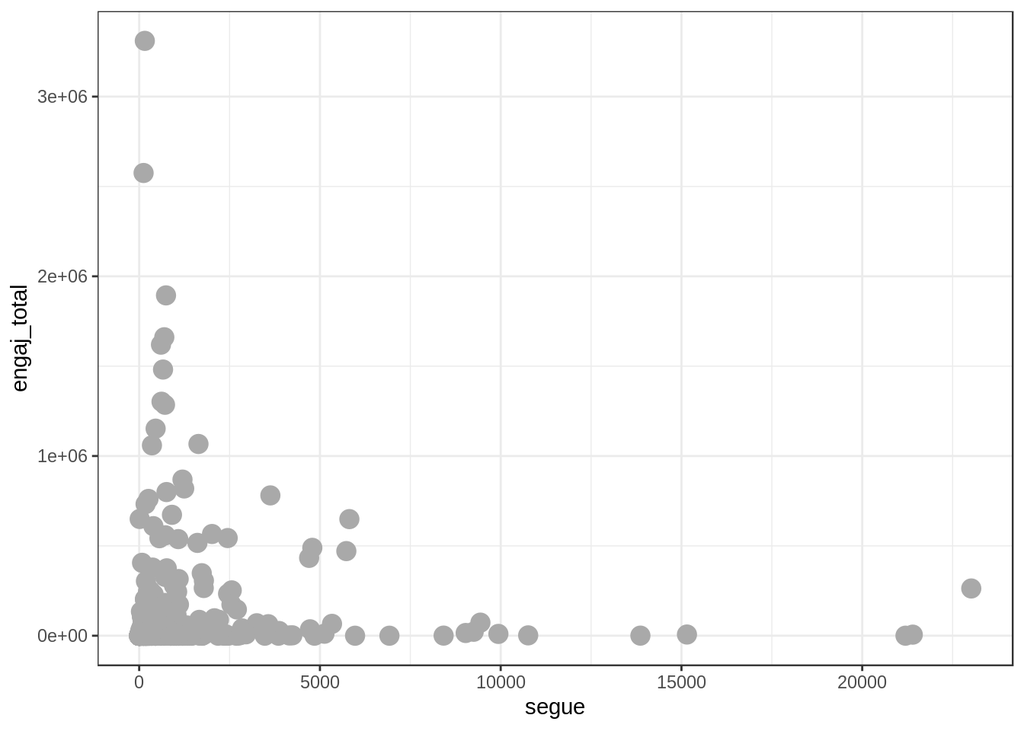

```r
 congressistas_com_twitter %>%
  ggplot(aes(x = segue, y = engaj_total)) +
  geom_point(colour = "darkgrey", size = 4)
```

```r
 congressistas_com_twitter %>%
   summarize(correlacao_pearson = cor(segue, engaj_total, method="pearson"),
             correlacao_spearman = cor(segue, engaj_total, method="spearman"),
             correlacao_kendall = cor(segue, engaj_total, method="kendall"))
```

```
## # A tibble: 1 x 3
##   correlacao_pearson correlacao_spearman correlacao_kendall
##                <dbl>               <dbl>              <dbl>
## 1             0.0426               0.760              0.578
```

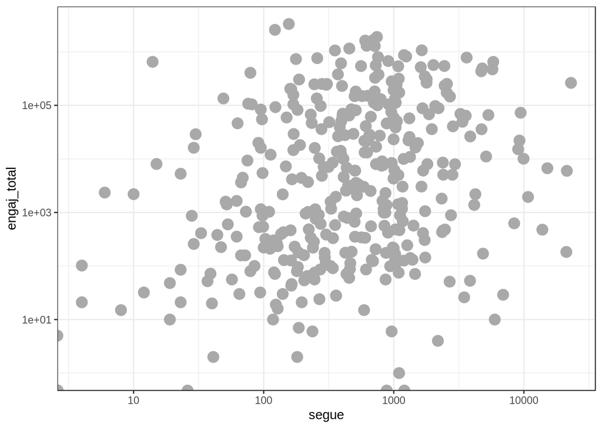

```r
 congressistas_com_twitter %>%
  ggplot(aes(x = segue, y = engaj_total)) +
  geom_point(colour = "darkgrey", size = 4) +
  scale_x_log10() +
  scale_y_log10()
```